```python
import plotly.io as pio
pio.renderers.default = 'notebook'
```

# Multiple Linear Regression with Dataset mtcars

We will be using a multiple linear regression model to try and find relationships between variables in mtcars, specifically variables  
**mpg** (miles per gallon), **qsec** (1/4 mile time), and **am** (transmission type).

## Multiple Linear Regression assumptions

1. The model has a linear relationship to the parameters (the regression coefficients).
2. Residuals have a covariance of zero and are uncorrelated for time series data.
3. The residuals are normally distributed and their anticipated mean value is zero.
4. Homogeneity of variance: the size of the error in our prediction doesn’t change significantly across the values of the independent variable.
5. Independence of observations: the observations in the dataset were collected using statistically valid sampling methods, and there are no hidden relationships among observations.
6. There is no multicollinearity (no two independent variables are highly correlated).

```python
#imports
import os
import numpy as np
import pandas as pandas
import matplotlib
import matplotlib.pyplot as plt
from sklearn import linear_model
import seaborn as sns
import scipy.stats as stats
matplotlib.style.use('ggplot')
from sklearn import metrics
from sklearn import datasets, linear_model
from sklearn.linear_model import LinearRegression
import statsmodels.api as sm
```

```python
#load the dataset mtcars
mtcars = pandas.read_csv(r"C:\Users\Rbrig\Downloads\mtcars\mtcars\mtcars.csv")
```

```python
#get a visual of the statistics of mtcars
mtcars.describe()
```

|  | mpg | cyl | disp | hp | drat | wt | qsec | vs | am | gear | carb |
| --- | --- | --- | --- | --- | --- | --- | --- | --- | --- | --- | --- |
| count | 32.000000 | 32.000000 | 32.000000 | 32.000000 | 32.000000 | 32.000000 | 32.000000 | 32.000000 | 32.000000 | 32.000000 | 32.0000 |
| mean | 20.090625 | 6.187500 | 230.721875 | 146.687500 | 3.596563 | 3.217250 | 17.848750 | 0.437500 | 0.406250 | 3.687500 | 2.8125 |
| std | 6.026948 | 1.785922 | 123.938694 | 68.562868 | 0.534679 | 0.978457 | 1.786943 | 0.504016 | 0.498991 | 0.737804 | 1.6152 |
| min | 10.400000 | 4.000000 | 71.100000 | 52.000000 | 2.760000 | 1.513000 | 14.500000 | 0.000000 | 0.000000 | 3.000000 | 1.0000 |
| 25% | 15.425000 | 4.000000 | 120.825000 | 96.500000 | 3.080000 | 2.581250 | 16.892500 | 0.000000 | 0.000000 | 3.000000 | 2.0000 |
| 50% | 19.200000 | 6.000000 | 196.300000 | 123.000000 | 3.695000 | 3.325000 | 17.710000 | 0.000000 | 0.000000 | 4.000000 | 2.0000 |
| 75% | 22.800000 | 8.000000 | 326.000000 | 180.000000 | 3.920000 | 3.610000 | 18.900000 | 1.000000 | 1.000000 | 4.000000 | 4.0000 |
| max | 33.900000 | 8.000000 | 472.000000 | 335.000000 | 4.930000 | 5.424000 | 22.900000 | 1.000000 | 1.000000 | 5.000000 | 8.0000 |

### First Model

```python
#creating a model with all the variables of mtcars

X = mtcars.iloc[:,2:]
Y = mtcars.mpg

X2 = sm.add_constant(X)
est = sm.OLS(Y, X2).fit()
print(est.summary2())
```

```
                 Results: Ordinary least squares
=================================================================
Model:              OLS              Adj. R-squared:     0.807
Dependent Variable: mpg              AIC:                161.7098
Date:               2024-02-27 13:40 BIC:                177.8329
No. Observations:   32               Log-Likelihood:     -69.855
Df Model:           10               F-statistic:        13.93
Df Residuals:       21               Prob (F-statistic): 3.79e-07
R-squared:          0.869            Scale:              7.0235
-------------------------------------------------------------------
          Coef.    Std.Err.      t      P>|t|     [0.025     0.975]
-------------------------------------------------------------------
const    12.3034    18.7179    0.6573   0.5181   -26.6226   51.2293
cyl      -0.1114     1.0450   -0.1066   0.9161    -2.2847    2.0618
disp      0.0133     0.0179    0.7468   0.4635    -0.0238    0.0505
hp       -0.0215     0.0218   -0.9868   0.3350    -0.0668    0.0238
drat      0.7871     1.6354    0.4813   0.6353    -2.6138    4.1881
wt       -3.7153     1.8944   -1.9612   0.0633    -7.6550    0.2243
qsec      0.8210     0.7308    1.1234   0.2739    -0.6988    2.3409
vs        0.3178     2.1045    0.1510   0.8814    -4.0588    4.6943
am        2.5202     2.0567    1.2254   0.2340    -1.7568    6.7973
gear      0.6554     1.4933    0.4389   0.6652    -2.4500    3.7608
carb     -0.1994     0.8288   -0.2406   0.8122    -1.9229    1.5241
-----------------------------------------------------------------
Omnibus:              1.907        Durbin-Watson:           1.861
Prob(Omnibus):        0.385        Jarque-Bera (JB):        1.747
Skew:                 0.521        Prob(JB):                0.418
Kurtosis:             2.526        Condition No.:           12213
=================================================================
Notes:
[1] Standard Errors assume that the covariance matrix of the
errors is correctly specified.
[2] The condition number is large, 1.22e+04. This might indicate
that there are strong multicollinearity or other numerical
problems.
```

## Diagnosing a Multiple Linear Regression Model

**1. Adjusted $ R^2 $**

- $ R^2 $ measures how well the model fits the data. It interprets well in simple linear regression, but not in multiple linear regression.
- This is because as the number of independent variables increases, $ R^2 $ tends to increase even if there is no significant relation between the target and the explanatory variable.
- To fix this issue, $ R^2 $ is adjusted, and then defined as
  $$ R^2 = 1−(1−R^2) \frac{n−1}{ n−p−1} $$ where p is number of explanatory variables in the model.

The adjusted $ R^2 $ value of our multiple linear regression model is 0.807, which means about 80% of the variation in the dependent variable is explained by the model.

**2. Hypothesis test, T-test, and P Value**

- The t-test is used to check whether the relationship between the dependent and independent variable is statistically significant or not at a given significance level (is there a relationship between x and y).
- If the t-statistic value is higher than the t-critical value at a given significance level, we reject the null hypothesis.  
  Otherwise, we fail to reject null hypothesis (that there is no relationship between x and y).
- We want to know the p value from our t-test.
- P-value is defined as the probability under the assumption of no effect or no difference (null hypothesis), of obtaining a result equal to or more extreme than what was actually observed.
- We want our p value to be less than 0.05, this means our data is significant.
- In the summary table of our multiple linear regression model, we see many variables have p-value > 0.05. This indicates multicollinearity in our model.

**3. Multicollinearity and Variance Inflation Factor (VIF)**

- Multicollinearity occurs when two or more independent variables in a regression model are strongly correlated with each other.
- Multicollinearity undermines the statistical significance of an independent variable.
- Variance Inflation Factor measures the magnitude of multicollinearity.
- VIF is given by $ \frac{1}{1-R^2} $
- VIF is usually interpreted on a scale:  
  VIF < 5: The variable has low multicollinearity (no significant issue).  
  VIF between 5 and 10: The variable has moderate multicollinearity (requires further investigation).  
  VIF > 10: The variable has high multicollinearity (serious issue, consider mitigation techniques).

### Variance Inflation Factor Table

```python
#create and view a table of varibles and their corresponding VIF
from statsmodels.stats.outliers_influence import variance_inflation_factor

vif=[variance_inflation_factor(X.values, j) for j in range(X.shape[1])]
vif_factor=pandas.DataFrame({'VIF': vif},index=X.columns)
vif_factor
```

|  | VIF |
| --- | --- |
| cyl | 112.629828 |
| disp | 98.930791 |
| hp | 56.047781 |
| drat | 132.214353 |
| wt | 182.948049 |
| qsec | 317.534376 |
| vs | 8.752581 |
| am | 7.412020 |
| gear | 119.804879 |
| carb | 32.213836 |

Since the VIF of all the variables we are interested are > 4, we will check the correlation between features using a correlation matrix.

### Correlation Matrix

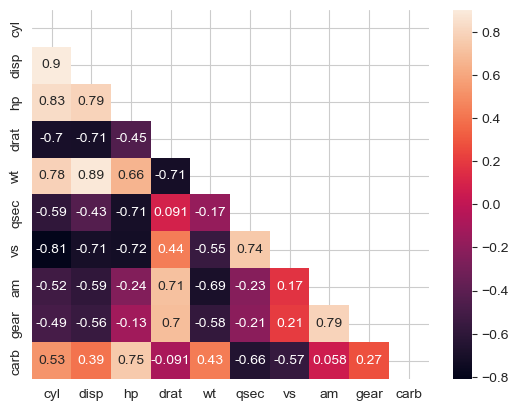

```python
#creating and displaying correlation matrix
sns.set_style("whitegrid")
mask = np.triu(np.ones_like(X.corr()))
corr = sns.heatmap(X.corr(), annot=True, mask=mask)
```

**4. Selecting Variables**  
Our correlation matrix shows that there is a strong correlation between certain variables.  
Correlation coefficients whose magnitude are between 0.7 and 0.9 indicate variables which can be considered strongly correlated.

- cyl:  
  vs, wt, drat, hp, disp
- hp:  
  carb, vs, qsec
- drat:  
  gear, am, wt

We will select one variable from each group to prevent multicollinearity.  
We select the variables we are interested in (wt, qsec, am).

### Variance Inflation Factor and P values Table

```python
#create and display table with VIF and p values
vif_factor['p-values']=est.pvalues[1:]
vif_factor
```

|  | VIF | p-values |
| --- | --- | --- |
| cyl | 112.629828 | 0.916087 |
| disp | 98.930791 | 0.463489 |
| hp | 56.047781 | 0.334955 |
| drat | 132.214353 | 0.635278 |
| wt | 182.948049 | 0.063252 |
| qsec | 317.534376 | 0.273941 |
| vs | 8.752581 | 0.881423 |
| am | 7.412020 | 0.233990 |
| gear | 119.804879 | 0.665206 |
| carb | 32.213836 | 0.812179 |

### Second Model

```python
#create multiple linear regression model with variables wt, qsec, am
X3 = X2[['const','wt','qsec','am']]
est2 = sm.OLS(Y, X3).fit()
print(est2.summary2())
```

```
                 Results: Ordinary least squares
=================================================================
Model:              OLS              Adj. R-squared:     0.834
Dependent Variable: mpg              AIC:                152.1194
Date:               2024-02-27 13:40 BIC:                157.9823
No. Observations:   32               Log-Likelihood:     -72.060
Df Model:           3                F-statistic:        52.75
Df Residuals:       28               Prob (F-statistic): 1.21e-11
R-squared:          0.850            Scale:              6.0459
-------------------------------------------------------------------
           Coef.    Std.Err.      t      P>|t|     [0.025    0.975]
-------------------------------------------------------------------
const      9.6178     6.9596    1.3819   0.1779   -4.6383   23.8739
wt        -3.9165     0.7112   -5.5069   0.0000   -5.3733   -2.4597
qsec       1.2259     0.2887    4.2467   0.0002    0.6346    1.8172
am         2.9358     1.4109    2.0808   0.0467    0.0457    5.8259
-----------------------------------------------------------------
Omnibus:              2.574        Durbin-Watson:           1.714
Prob(Omnibus):        0.276        Jarque-Bera (JB):        2.213
Skew:                 0.540        Prob(JB):                0.331
Kurtosis:             2.297        Condition No.:           296
=================================================================
Notes:
[1] Standard Errors assume that the covariance matrix of the
errors is correctly specified.
```

Adjusted $ R^2 $ of our new model is higher than the old one at 83.4%.  
Multicollinearity is taken care of, and all the variables have p-values < 0.05, so they are significant.

**5. Residual Analysis**  
Now the rest of our assumptions must be met.  
First, we make sure residuals are normally distributed

### Plot of Probabilities vs Residuals

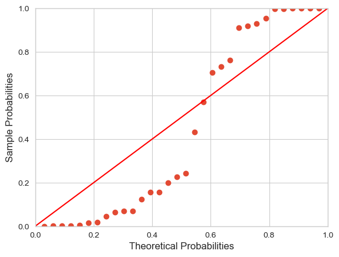

```python
#test for normality of residuals
probplot = sm.ProbPlot(est2.resid)
plt.figure()
probplot.ppplot(line='45')
plt.show()
```

Next, we test for homogeneity of variance.

### Plot of Predicted Values vs Residual VaLues

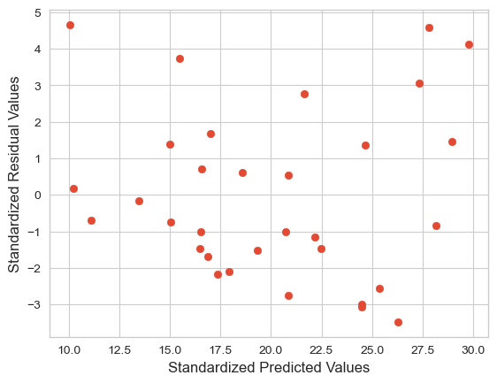

```python
def standardized_values(vals):
    return (vals - vals.mean())/vals.std()
plt.scatter(est2.fittedvalues, est2.resid)
plt.xlabel("Standardized Predicted Values")
plt.ylabel("Standardized Residual Values")
plt.show()
```

The residuals are random and do not follow any pattern. This means the residuals have constant variance (homogeneity of variance).

### Conclusions

We get the equation  
$ (mpg) = 9.618 − 3.917 (wt) + 1.226 (qsec) + 2.936 (am) $

Miles per gallon (**mpg**) is positively correlated with 1/4 mile time (**qsec**), and transmission type (**am**), and negatively correlated with weight (**wt**) of the car.

### Sources

- mtcars download https://gist.github.com/seankross/a412dfbd88b3db70b74b